# Thera Bank Personal Loan Campaign

### Bivariate Plots

- Not very useful to me, in this specific question

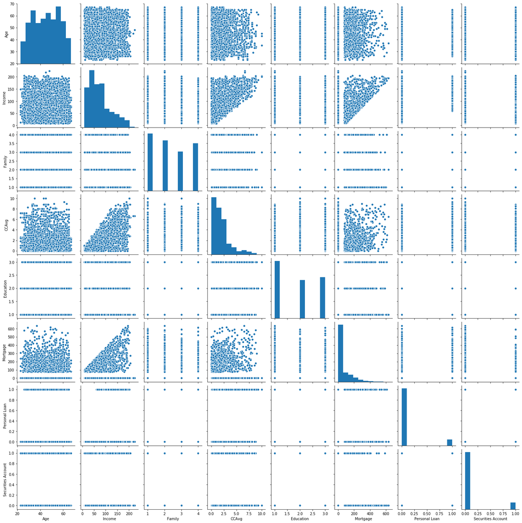

```python
sns.pairplot(dataplot)
```

### Get data model ready

#### First Pass will be Logistic Regression Model

```python
from sklearn.model_selection import train_test_split
from sklearn.linear_model import LogisticRegression
from sklearn.metrics import accuracy_score
from sklearn.metrics import classification_report
from sklearn.metrics import confusion_matrix
from sklearn.metrics import roc_curve,auc
```

```python
X=credit_df.drop('Personal Loan',axis=1)
y=credit_df['Personal Loan']

X_train,X_test,y_train,y_test=train_test_split(X,y,random_state=1)
```

```python
LRegmodel=LogisticRegression()
LRegmodel.fit(X_train,y_train)
```

```
LogisticRegression(C=1.0, class_weight=None, dual=False, fit_intercept=True,
                   intercept_scaling=1, l1_ratio=None, max_iter=100,
                   multi_class='auto', n_jobs=None, penalty='l2',
                   random_state=None, solver='lbfgs', tol=0.0001, verbose=0,
                   warm_start=False)
```

```python
y_pred=LRegmodel.predict(X_test)
print(classification_report(y_test,y_pred))
print(accuracy_score(y_test,y_pred))
print(confusion_matrix(y_test,y_pred))
```

```
              precision    recall  f1-score   support

           0       0.95      0.98      0.97      1121
           1       0.76      0.57      0.65       129

    accuracy                           0.94      1250
   macro avg       0.86      0.77      0.81      1250
weighted avg       0.93      0.94      0.93      1250

0.9368
[[1098   23]
 [  56   73]]
```

```python
LRegProb=LRegmodel.predict_proba(X_test)
fpr1,tpr1,thresholds1=roc_curve(y_test,LRegProb[:,1])
roc_auc1=auc(fpr1,tpr1)
print("Area under the Curve: %f" % roc_auc1)
```

```
Area under the Curve: 0.935129
```

### - Evaluation Model Criteria

- Accuracy 94%
- Type I error = 23(FP) , Type II error = 56 (FN)
- out of the total number of clients that applied for a Loan, the model was able to pick up 57% of them (Recall value)
- Area under the Curve is 93.5%, considering as such a good model (80% or more is considered a good model, and 50% or less is a Bad Model)
- Although the model shows a great accuracy, nevertheless Recall is quite low 57% only.